# What is Astropy?

### Once upon a time ...

Independent projects existed around the world to help astronomers used Python for their daily tasks. These tasks included

- Handling a variety of formats of tabular data.
- Dealing with FITS files.
- Dealing with World Coordinate Systems.
- Do cosmological calculations.
- Invoke Virtual Observatory based queries. and so on ...

### Different developers, different teams, different interfaces.

Relatively poor interoperability.

## Enter Astropy!

Astropy is a community project that aims to unify these interfaces together into one common package useful for all astronomers.

## Affiliated Packages

These packages are an independent set of projects and thus not a part of the Astropy project. But the developers of these projects share the same vision of a unified interface/approach to doing things. And thus they sign up their packages as affiliated packages.

Look at: http://www.astropy.org/affiliated/index.html for more details.

## What Astropy can do?

**Lots!**

But we will attempt to cover here basics of a subset of features.

- Tables
- FITS files
- World Coordinates/Coordinate Systems
- Modeling
- Cosmology

# Tables

For low level access to reading ASCII tables, one can use the classes in the sub-module `astropy.io.ascii`. This is seldom required. We instead use `astropy.table` which is a higher level and more convenient API to dealing with tables. It is only when the higher level API has trouble loading your file, it might benefit you to move to the lower API and play around with it.

So, let's read out a simple table.

```python
# First, import the table class.
from astropy.table import Table

# Next, use its read method to read a table
demo_table = Table.read('demo.txt', format='ascii')
```

That's it. The table is loaded. Before we move further, couple of points.

- `format="ascii"` is needed for all ASCII files since they can have a variety of extensions such as .dat, .txt, .csv etc.
- For files with extensions such as .vot, .xml (VOTables), .fits (FITS Tables) etc. the format need not be given.
- If an ASCII file does not load, it means the tables violate some assumptions in terms of structure. In this case, refer to documentation of astropy.io.ascii and try passing various flags to help Astropy interpret the file.

Once a file has been loaded as a table object, one may simply print it to see its contents.

```python
print(demo_table)
```

```
Name  obs_date  mag_b mag_v
---- ---------- ----- -----
 M31 2012-01-02  17.0  17.5
 M31 2012-01-02  17.1  17.4
M101 2012-01-02  15.1  13.5
 M82 2012-02-14  16.2  14.5
 M31 2012-02-14  16.9  17.3
 M82 2012-02-14  15.2  15.5
M101 2012-02-14  15.0  13.6
 M82 2012-03-26  15.7  16.5
M101 2012-03-26  15.1  13.5
M101 2012-03-26  14.8  14.3
```

If you need some kind of control over how the table is formatted, use .pprint() method.

```python
demo_table.pprint(show_dtype=True, align='^', show_name=False)
```

```
str4   str10    float64 float64
---- ---------- ------- -------
M31  2012-01-02   17.0    17.5
M31  2012-01-02   17.1    17.4
M101 2012-01-02   15.1    13.5
M82  2012-02-14   16.2    14.5
M31  2012-02-14   16.9    17.3
M82  2012-02-14   15.2    15.5
M101 2012-02-14   15.0    13.6
M82  2012-03-26   15.7    16.5
M101 2012-03-26   15.1    13.5
M101 2012-03-26   14.8    14.3
```

There are other ways to print the tables.

The following will only work in a terminal, not in a iPython notebook.

```
demo_table.more()
```

Following is better suited for a Notebook

```
demo_table.show_in_notebook()
```

And following to generate a pure HTML table.

```
demo_table.show_in_browser()
```

```python
demo_table.show_in_browser()
```

## Some basic properties of tables

```python
# Let's get the length of the table in rows.
num_rows = len(demo_table)
```

```python
# And get the column names.
print(demo_table.colnames)
```

```
['Name', 'obs_date', 'mag_b', 'mag_v']
```

```python
# Some formats support additional metadata.
# In this case we get an empty OrderedDict.
print(demo_table.meta)
```

```
OrderedDict()
```

## Accessing Data from Astropy table

```python
# Get a column
print(demo_table['Name'])
```

```
Name
----
 M31
 M31
M101
 M82
 M31
 M82
M101
 M82
M101
M101
```

```python
# Get many columns.
print(demo_table['Name', 'mag_v'])
```

```
Name mag_v
---- -----
 M31  17.5
 M31  17.4
M101  13.5
 M82  14.5
 M31  17.3
 M82  15.5
M101  13.6
 M82  16.5
M101  13.5
M101  14.3
```

```python
# Get a row.
print(demo_table[1])
```

```
Name  obs_date  mag_b mag_v
---- ---------- ----- -----
 M31 2012-01-02  17.1  17.4
```

```python
# Get many rows.
print(demo_table[0:3])
```

```
Name  obs_date  mag_b mag_v
---- ---------- ----- -----
 M31 2012-01-02  17.0  17.5
 M31 2012-01-02  17.1  17.4
M101 2012-01-02  15.1  13.5
```

```python
# Hand pick rows.
print(demo_table[[1,4,6]])
```

```
Name  obs_date  mag_b mag_v
---- ---------- ----- -----
 M31 2012-01-02  17.1  17.4
 M31 2012-02-14  16.9  17.3
M101 2012-02-14  15.0  13.6
```

You can chain row and column wise access syntaxes to get sub-sections of the table. Below we print these out but you can always replace print() by an assignment to extract the sub-sections.

```python
print(demo_table['Name', 'obs_date'][0:4])
```

```
Name  obs_date
---- ----------
 M31 2012-01-02
 M31 2012-01-02
M101 2012-01-02
 M82 2012-02-14
```

And using assignments, you can change the values.

```
demo_table['Name'] = [ , , , ... ]
demo_table['Name'][0] = 'Something'
```

## Adding/Removing columns.

```python
# Method 1
import numpy as np
demo_table['NewColumn'] = np.arange(len(demo_table))
print(demo_table)
```

```
Name  obs_date  mag_b mag_v NewColumn
---- ---------- ----- ----- ---------
 M31 2012-01-02  17.0  17.5         0
 M31 2012-01-02  17.1  17.4         1
M101 2012-01-02  15.1  13.5         2
 M82 2012-02-14  16.2  14.5         3
 M31 2012-02-14  16.9  17.3         4
 M82 2012-02-14  15.2  15.5         5
M101 2012-02-14  15.0  13.6         6
 M82 2012-03-26  15.7  16.5         7
M101 2012-03-26  15.1  13.5         8
M101 2012-03-26  14.8  14.3         9
```

```python
# Method 2
from astropy.table import Column
newcol = Column(np.arange(len(demo_table)), name='NewColumn2')
demo_table.add_column(newcol, index=0)
print(demo_table)
```

```
NewColumn2 Name  obs_date  mag_b mag_v NewColumn
---------- ---- ---------- ----- ----- ---------
         0  M31 2012-01-02  17.0  17.5         0
         1  M31 2012-01-02  17.1  17.4         1
         2 M101 2012-01-02  15.1  13.5         2
         3  M82 2012-02-14  16.2  14.5         3
         4  M31 2012-02-14  16.9  17.3         4
         5  M82 2012-02-14  15.2  15.5         5
         6 M101 2012-02-14  15.0  13.6         6
         7  M82 2012-03-26  15.7  16.5         7
         8 M101 2012-03-26  15.1  13.5         8
         9 M101 2012-03-26  14.8  14.3         9
```

```python
# Let's remove columns.
demo_table.remove_columns(['NewColumn', 'NewColumn2'])
print(demo_table)
```

```
Name  obs_date  mag_b mag_v
---- ---------- ----- -----
 M31 2012-01-02  17.0  17.5
 M31 2012-01-02  17.1  17.4
M101 2012-01-02  15.1  13.5
 M82 2012-02-14  16.2  14.5
 M31 2012-02-14  16.9  17.3
 M82 2012-02-14  15.2  15.5
M101 2012-02-14  15.0  13.6
 M82 2012-03-26  15.7  16.5
M101 2012-03-26  15.1  13.5
M101 2012-03-26  14.8  14.3
```

To remove rows.

```
demo_table.remove_row(4)
OR
demo_table.remove_rows([1, 3, 7])
```

## Sort the table

```python
# Sort by name, use mag_b for breaking ties.
demo_table.sort(['Name', 'mag_b'])
print(demo_table)
```

```
Name  obs_date  mag_b mag_v
---- ---------- ----- -----
M101 2012-03-26  14.8  14.3
M101 2012-02-14  15.0  13.6
M101 2012-01-02  15.1  13.5
M101 2012-03-26  15.1  13.5
 M31 2012-02-14  16.9  17.3
 M31 2012-01-02  17.0  17.5
 M31 2012-01-02  17.1  17.4
 M82 2012-02-14  15.2  15.5
 M82 2012-03-26  15.7  16.5
 M82 2012-02-14  16.2  14.5
```

Use `demo_table.reverse()` to reverse the order.

## Groups

```python
demo_table = Table.read('demo.txt', format='ascii')
grouped = demo_table.group_by('Name')
print(grouped)
```

```
Name  obs_date  mag_b mag_v
---- ---------- ----- -----
M101 2012-01-02  15.1  13.5
M101 2012-02-14  15.0  13.6
M101 2012-03-26  15.1  13.5
M101 2012-03-26  14.8  14.3
 M31 2012-01-02  17.0  17.5
 M31 2012-01-02  17.1  17.4
 M31 2012-02-14  16.9  17.3
 M82 2012-02-14  16.2  14.5
 M82 2012-02-14  15.2  15.5
 M82 2012-03-26  15.7  16.5
```

```python
print(grouped.groups[0])
```

```
Name  obs_date  mag_b mag_v
---- ---------- ----- -----
M101 2012-01-02  15.1  13.5
M101 2012-02-14  15.0  13.6
M101 2012-03-26  15.1  13.5
M101 2012-03-26  14.8  14.3
```

```python
print(grouped.groups[1])
```

```
Name  obs_date  mag_b mag_v
---- ---------- ----- -----
 M31 2012-01-02  17.0  17.5
 M31 2012-01-02  17.1  17.4
 M31 2012-02-14  16.9  17.3
```

### Group Wise Reduction

```python
grouped.groups.aggregate(np.mean)
```

```
WARNING: Cannot aggregate column 'obs_date' with type '<U10' [astropy.table.groups]
```

<Table length=3>

| Name str4 | mag_b float64 | mag_v float64 |
| --- | --- | --- |
| M101 | 15.0 | 13.725 |
| M31 | 17.0 | 17.4 |
| M82 | 15.7 | 15.5 |

### Other options for you to play around - vstack, hstack, joins etc.

# Dealing with FITS files

Recall that FITS stands for "Flexible Image Transport System". It is a file format designed by astronomers. And it is indeed flexible - it can store images (as 2-d arrays) and it can store tables (ASCII and binary). And a given file can have both - this allows one to attach tabular data directly to images. eg. a catalog of photometry can be attached to the image from which it was extracted.

Recall that a FITS file is made of one or more **header/data units** (HDUs).

- Each HDU is made of a **header unit** which contains metadata in the form of a key-value pair. This part is compulsory.
- An optional component within a HDU is the **data unit** which contains the data unit.

Astropy has a sub-module for handling FITS files. Let's see how to load a file.

```python
# First import the sub-module
from astropy.io import fits

# To load a FITS file
hdulist = fits.open('example.fits')

# This is a special type of list.
# Supports more or less all list operations.
# And some more (like writeto)
print(type(hdulist))
```

```
<class 'astropy.io.fits.hdu.hdulist.HDUList'>
```

```python
# HDUList contains HDU object.
print(type(hdulist[0]))
```

```
<class 'astropy.io.fits.hdu.image.PrimaryHDU'>
```

When dealing with a new file, the first obvious step is to examine the file and understand how data is organized in it.

```python
print(hdulist.info())
```

```
Filename: example.fits
No.    Name         Type      Cards   Dimensions   Format
  0  PRIMARY     PrimaryHDU      71   (512, 512)   int16
None
```

So, this simple file contains just one HDU which has 71 entries in its header (cards) and data which has dimensions 512 x 512

Let's now see how the header of a given HDU can be examined. For convenience, we will create a variable pointing to it.

```python
header = hdulist[0].header
print(header.cards)
```

```
('SIMPLE', True, 'Fits standard')
('BITPIX', 16, 'Bits per pixel')
('NAXIS', 2, 'Number of axes')
('NAXIS1', 512, 'Axis length')
('NAXIS2', 512, 'Axis length')
('EXTEND', False, 'File may contain extensions')
('ORIGIN', 'NOAO-IRAF FITS Image Kernel July 2003', 'FITS file originator')
('DATE', '2017-02-17T04:36:31', 'Date FITS file was generated')
('IRAF-TLM', '2017-02-17T04:36:31', 'Time of last modification')
('OBJECT', 'm51  B  600s', 'Name of the object observed')
('IRAF-MAX', 19936.0, 'DATA MAX')
('IRAF-MIN', -1.0, 'DATA MIN')
('CCDPICNO', 53, 'ORIGINAL CCD PICTURE NUMBER')
('ITIME', 600, 'REQUESTED INTEGRATION TIME (SECS)')
('TTIME', 600, 'TOTAL ELAPSED TIME (SECS)')
('OTIME', 600, 'ACTUAL INTEGRATION TIME (SECS)')
('DATA-TYP', 'OBJECT (0)', 'OBJECT,DARK,BIAS,ETC.')
('DATE-OBS', '05/04/87', 'DATE DD/MM/YY')
('RA', '13:29:24.00', 'RIGHT ASCENSION')
('DEC', '47:15:34.00', 'DECLINATION')
('EPOCH', 0.0, 'EPOCH OF RA AND DEC')
('ZD', '22:14:00.00', 'ZENITH DISTANCE')
('UT', ' 9:27:27.00', 'UNIVERSAL TIME')
('ST', '14:53:42.00', 'SIDEREAL TIME')
('CAM-ID', 1, 'CAMERA HEAD ID')
('CAM-TEMP', -106.22, 'CAMERA TEMPERATURE, DEG C')
('DEW-TEMP', -180.95, 'DEWAR TEMPRATURE, DEG C')
('F1POS', 2, 'FILTER BOLT I POSITION')
('F2POS', 0, 'FILTER BOLT II POSITION')
('TVFILT', 0, 'TV FILTER')
('CMP-LAMP', 0, 'COMPARISON LAMP')
('TILT-POS', 0, 'TILT POSITION')
('BIAS-PIX', 0, '')
('BI-FLAG', 0, 'BIAS SUBTRACT FLAG')
('BP-FLAG', 0, 'BAD PIXEL FLAG')
('CR-FLAG', 0, 'BAD PIXEL FLAG')
('DK-FLAG', 0, 'DARK SUBTRACT FLAG')
('FR-FLAG', 0, 'FRINGE FLAG')
('FR-SCALE', 0.0, 'FRINGE SCALING PARAMETER')
('TRIM', 'Apr 22 14:11 Trim image section is [3:510,3:510]', '')
```

[output cut: 16 more lines]

[output not shown]

Header objects behave almost like dictionaries. So, you can query values and change them using a dictionary like syntax.

```python
print(header['NAXIS1'])
```

```
512
```

```python
print(header['NAXIS2'])
```

```
512
```

```python
header['INSTRMNT'] = 'MyTelescope'
```

The data can be accessed using the data attribute of the HDU.

```python
data = hdulist[0].data
print(type(data))
```

```
<class 'numpy.ndarray'>
```

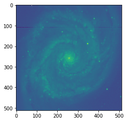

```python
%matplotlib inline
import matplotlib.pyplot as plt
import numpy as np
plt.imshow(np.log(data))
```

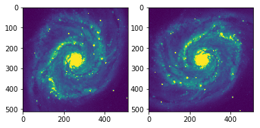

```python
# Images in ZScale

from astropy.visualization import ZScaleInterval
z = ZScaleInterval()
z1, z2 = z.get_limits(data)
fig, axes = plt.subplots(nrows=1, ncols=2)
axes[0].imshow(data, vmin=z1, vmax=z2)
axes[1].imshow(data.T, vmin=z1, vmax=z2)
```

## Making a FITS file.

```python
import numpy.random as nr
data = nr.normal(0,1,262144).reshape(512, 512)

hdulist = fits.HDUList()
hdu1 = fits.PrimaryHDU()
hdu1.data = data
hdulist.append(hdu1)

hdulist.writeto('myFile.fits')
```

Let's extend the above code in order to be able to add a table as well.

```python
col1 = fits.Column(name='col1', format='E', array=nr.normal(0, 1, 10))
col2 = fits.Column(name='col2', format='E', array=nr.normal(3, 1, 10))
cols = fits.ColDefs([col1, col2])
hdu2 = fits.BinTableHDU.from_columns(cols)

hdulist.append(hdu2)
hdulist.writeto('myFile2.fits')
```

## Convenience Functions

Astropy's io.fits library comes with a whole bunch of convenience functions. This makes common operations with FITS file much easier.

```
header = fits.getheader('somefile.fits')
naxis1 = fits.getval('somefile.fits', 'naxis1', 1)
data = fits.getdata('some.fits', 2)

fits.writeto('some.fits', data, header)
fits.append('some.fits', data, header)
fits.update('some.fits, data, header, 1)
```

# World Coordinate Systems

If you open an image is ds9 or any other image viewer, you will notice that as the mouse pointer moves across various regions in the image, a part of the window will reflect the current coordinates in some coordinate system. This is possible because the image header contains a whole bunch of keywords which can be used to compute the coordinates as a function of the pixel coordinates.

What one needs is the coordinate for one pixel and then variation in coordinates for every pixel of movement. But if the image is very large, the curvature of the sky can become important. Then additional information to account for second order effects will need to be recorded

Let's see how a good fraction of all this is handled using Astropy.

Simple steps:

- Get hold of the header.
- Pass it to a WCS object constructor.
- And use this object for coordinate conversions.

```python
import astropy.wcs as wcs
hdulist = fits.open('example2.fits')
w = wcs.WCS(hdulist[0].header)
print(w)
```

```
WCS Keywords

Number of WCS axes: 2
CTYPE : 'RA---TAN'  'DEC--TAN'
CRVAL : 205.4864335  47.266862983333333
CRPIX : -3929.5565883887348  377.06044565265529
PC1_1 PC1_2  : 0.02528041441746252  2.2668333052882081e-05
PC2_1 PC2_2  : -1.9834163566217479e-05  0.025288468441936381
CDELT : -0.01868178756738699  0.01868178756738699
NAXIS : 777  777
```

```
WARNING: FITSFixedWarning: 'datfix' made the change 'Changed '08/04/56          ' to '1956-04-08''. [astropy.wcs.wcs]
```

```python
# Convert pixels to coordinates.
w.wcs_pix2world(100, 100, 1)
```

```
[array(202.6903727881603), array(47.10039635883531)]
```

```python
w.wcs_pix2world([100, 105], [100, 105], 1)
```

```
[array([ 202.69037279,  202.68677899]), array([ 47.10039636,  47.10266995])]
```

```python
w.wcs_world2pix(202.69, 47.1, 1)
```

```
[array(100.56778084479777), array(99.18105789968297)]
```

```python
w.calc_footprint()
```

```
array([[ 202.76146626,   47.05535561],
       [ 202.74206475,   47.42164629],
       [ 202.2009436 ,   47.40718098],
       [ 202.22406523,   47.04102483]])
```

## Some convenience functions.

There are some utilities provided for your convenience which make coordinate to pixel and vice versa calculations much simple.

```python
output = wcs.utils.pixel_to_skycoord(100, 100, w)
output
```

```
<SkyCoord (FK5: equinox=2000.0): (ra, dec) in deg
    ( 202.68965405,  47.10085109)>
```

Remember: This is capable of ignoring higher dimensions in WCS in radio data, for example.

The output here is a special object known as a sky coordinate object. This can be created by saying,

```
from astropy.coordinates import SkyCoord
c = SkyCoord(10, 20, unit='deg')
```

```python
new = output.transform_to(astropy.coordinates.Galactic)
print(new)
```

```
<SkyCoord (Galactic): (l, b) in deg
    ( 104.37183205,  68.58518637)>
```

```python
from astropy.coordinates import SkyCoord
distance = output.separation(SkyCoord(202, 47, unit='deg'))
print(distance)
```

```
0d28m50.1524s
```

```python
print(output.ra, output.dec)
```

```
202d41m22.7546s 47d06m03.0639s
```

# Modeling

This is a library in Python designed to give you

- Access to commonly used models.
- As well as fit them to various data.

Let's see how to simply use models.

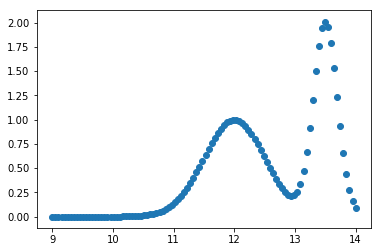

```python
from astropy.modeling import models
x = np.linspace(9, 14, 100)
gauss_example1 = models.Gaussian1D(amplitude=1.0, mean=12, stddev=0.5)
gauss_example2 = models.Gaussian1D(amplitude=2.0, mean=13.5, stddev=0.2)
gauss_total = gauss_example1 + gauss_example2
y = gauss_total(x)

plt.scatter(x,y)
```

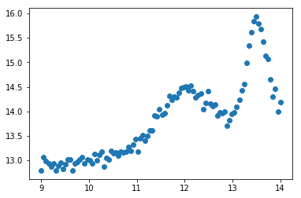

```python
y_noise = nr.normal(0, 0.1, len(x))
y_obs = 12 + 0.01*x**2 + y + y_noise
plt.scatter(x, y_obs)
```

We saw how trivial it is to use a model and actually evaluate it over a range. But a more useful thing we need to do with models is to fit some data. Now, pretend that x and y_obs are two arrays that contain our observed data. We can start by plotting the same.

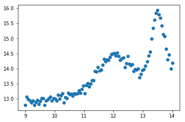

```python
plt.scatter(x, y_obs)
```

Once we have a plot, our next step is to choose a model. What model shall fit the data well? Let us assume that these are spectral features with some known wavelengths. So, we may assume that each feature is a Gaussian. To minimize number if independent parameters, we may also consider that the difference in the wavelengths is a constant. Such a constraint obviously comes from our prior knowledge of the physical system that generated the spectrum.

Next, these emission features clearly are not on their own - they are stop a continuum. Assuming that the continuum is not varying at a fast rate wrt wavelengths (X-axis), we can further assume that a quadratic polynomial suffices in accounting for this.

So, our model is a second order polynomial plus two Gaussians, with different means but separated by a known amount.

```python
# So, let us construct our model.
model = models.Gaussian1D(amplitude=1.0, mean=12.0, stddev=0.5) +\
        models.Gaussian1D(amplitude=1.0, mean=13.5, stddev=0.5) +\
        models.Polynomial1D(degree=2)
```

```python
print(model.param_names)
```

```
('amplitude_0', 'mean_0', 'stddev_0', 'amplitude_1', 'mean_1', 'stddev_1', 'c0_2', 'c1_2', 'c2_2')
```

```python
# Our model is not complete. We must supply our constraint.
def constraint_mean(model):
    mean_0 = model.mean_1 - 1.5
    return mean_0

model.mean_0.tied = constraint_mean
```

The model is ready. We have the data. What we finally need is a fitting algorithm. Let us choose the Marquardt Levenberg method.

```python
from astropy.modeling import fitting
fitter = fitting.LevMarLSQFitter()

model_fit = fitter(model, x, y_obs)
```

```
WARNING: The fit may be unsuccessful; check fit_info['message'] for more information. [astropy.modeling.fitting]
```

```python
model_fit.parameters
```

```
array([  0.99950225,  12.01472303,   0.49223779,   2.10232151,
        13.51472303,   0.22456776,   9.18323367,   0.52825358,  -0.01431427])
```

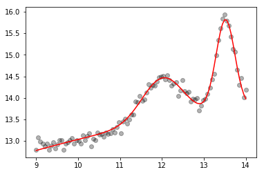

```python
plt.scatter(x, y_obs, color='black', alpha=0.3)
plt.plot(x, model_fit(x), color='red')
```

# Cosmology

You no longer need to open a web browser to access a cosmology calculator. You can do all this in Python using astropy's cosmology module. Let's see a quick demo.

```python
from astropy import cosmology
print(cosmology.parameters.available)
```

```
('Planck15', 'Planck13', 'WMAP9', 'WMAP7', 'WMAP5')
```

```python
# Let us choose a model out of one of the above...
from astropy.cosmology import Planck15
print(Planck15.H(1.5)) # what is the Hubble parameter at redshift 1.5?
print(Planck15.Ode(3)) # density parameter for dark energy at redshift z=3   (in units of critical density)
print(Planck15.critical_density(3))
print(Planck15.Tcmb(1000))
print(Planck15.angular_diameter_distance(2))
print(Planck15.arcsec_per_kpc_comoving(3))
print(Planck15.scale_factor(4))
```

```
159.16499068445535 km / (Mpc s)
0.0337380968474
1.7654629553988414e-28 g / cm3
2728.2255 K
1770.51301244141 Mpc
0.03168529375492998 arcsec / kpc
0.2
```

# Virtual Observatory Queries

```python
from astropy.vo.client import conesearch
from astropy.coordinates import SkyCoord
import astropy.units as u
available = conesearch.list_catalogs()
print(available)
```

[output not shown]

```python
c = SkyCoord.from_name('NGC4245')
print(c.ra, c.dec)
catalog = 'SDSS DR8 - Sloan Digital Sky Survey Data Release 8 2'
result = conesearch.conesearch(c, 0.01*u.degree, catalog_db=catalog)
```

```
184d24m11.5934s 29d36m28.832s
Trying http://wfaudata.roe.ac.uk/sdssdr8-dsa/DirectCone?DSACAT=SDSS_DR8&DSATAB=SpecObjAll&
```

[output not shown]

```python
print(type(result))
```

```
<class 'astropy.io.votable.tree.Table'>
```

```python
print(result)
```

```
     specObjID           bestObjID      ...             img
                                        ...
------------------- ------------------- ... ----------------------------
2513080399412881408 1237667211066081301 ... [-119 80 78 ..., 66 96 -126]
```

```python
print(result.array.size)
```

```
1
```

```python
print(result.array.dtype.names)
```

[output not shown]